# Etude par univers

Thomas FONTAINE, Dan GOLDMAN, Juliette LEMAINS et Nicolas ROBIN

14/12/2018

## 3.1 Evolution du CA par univers de produit et par année d’achat

3.1 Evolution du CA par univers de produit et par année d’achat Objectif: réaliser un histogramme presentant le CA par univers produit et par année d’achat

# library

```r
library(dplyr)
library(data.table)
```

```r
library(readxl)
library(assertthat)
library(xlsx)
library(stringr)
library(rAmCharts)
library(formattable)
library(RSQLite)
library(proto)
library(gsubfn)
library(sqldf)
library(ggplot2)
```

# Iimport des données

Etape 1 : Import des des données - la table article - la table ligne ticket - la table entete ticket

```r
#import de la table article source
articles_in <- read.csv2("C:/Users/dgoldman/Desktop/MBA - BIG DATA CDO/DataMining/projet transverse R/Projet R a rendre/DATA/REF_ARTICLE.csv", header = T, na.strings = "",
                      stringsAsFactors = FALSE, sep = "|", dec =",")

#import de la table ligne ticket
lignes_in <- read.csv2("C:/Users/dgoldman/Desktop/MBA - BIG DATA CDO/DataMining/projet transverse R/Projet R a rendre/DATA/LIGNES_TICKET.csv", header = T, na.strings = "",
                    stringsAsFactors = FALSE, sep = "|", dec =",")

#import de la table entete ticket
entete_in <- read.csv2("C:/Users/dgoldman/Desktop/MBA - BIG DATA CDO/DataMining/projet transverse R/Projet R a rendre/DATA/ENTETES_TICKET.csv", header = T, na.strings = "",
                    stringsAsFactors = FALSE, sep = "|", dec =",")
```

# modification sur de la table article

Etape 2 : Retravailler la table article. Copie de la table article en renommant le champ de l’identifiant article. Ajout d’un identifiant article dans la table article (cet identifiant apparait dans la table ligne ticket, il faut donc l’ajouter dans la table article pour pouvoir le comptabiliser).

```r
#copie de la table article et renommer l'id code article
article<-rename(articles_in, IDARTICLE = ï..CODEARTICLE)

# ajout de l ID article 395460 dans la table article
newarticle <- data.frame(IDARTICLE='395460',CODEUNIVERS='unknown',CODEFAMILLE='unknown', CODESOUSFAMILLE='unknown')
article<- rbind(article,newarticle)
```

# jointure interne entre la table ligne ticket et la table article

# exclusion de tous les articles qui n’ont jamais ete acheté

Etape 3 : Création d’une nouvelle table appelée ligne_aticle jointure interne entre la table ligne ticket et la table article. Tous les articles n’ayant eu aucun achat seront exclus de la table

```r
ligne_article<-merge(lignes_in,article, by="IDARTICLE", all=FALSE)
```

# agregation de la table ligne article pour faire un regroupement par code univers et ID ticket

Etape 4 : Agrégation du champs TOTAL (somme) de la table ligne par identifiant entete ticket et code univers

```r
#agregation de la table ligne article pour faire un regroupement par code univers et ID ticket
setDT(ligne_article)
ligne_univers<-ligne_article[, .(TOTAL=sum(TOTAL))
                        ,by=.(IDTICKET,CODEUNIVERS)]
```

# jointure interne entre la table entete ticket et la table ligne univers

Etape 5 : creation d’une nouvelle table appelée entete_ligne_univers jointure interne entre la table entete ticket et la table agrégée ligne univers

```r
#jointure interne entre la table entete ticket et la table ligne univers
entete_ligne_univers<-merge(entete_in,ligne_univers, by="IDTICKET", all=FALSE)
```

# Modification de la table entete_ligne_univers

Etape 6 : transformation du type pour le champs TIC_DATE pour recuperer l’année d’achat

```r
setDT(entete_ligne_univers)
#Modification du type pour le champs TIC_DATE en format date
entete_ligne_univers[,TIC_DATE:= as.Date(entete_ligne_univers$TIC_DATE)]
#recuperer l'année d'achat à partir du champs TIC_DATE transformé en format date
entete_ligne_univers[,TIC_YEAR:= year(entete_ligne_univers$TIC_DATE)]
```

# Agrégation de la table entete_ligne_univers par code univers et par année d’achat

Etape 7 : création d’une nouvelle table appelée ca_univers Agregation du champs TOTAL (somme) de la table entete_ligne_ticket par code univers et année d’achat Renommer le champs TIC_YEAR en ANNEE

```r
#table agrégé des CA par univers produit et par année
ca_univers<-entete_ligne_univers[, .(TOTAL=sum(TOTAL)),
                                    by=.(CODEUNIVERS, TIC_YEAR)]
#renommer le champ tic_year en année
setDT(ca_univers)
ca_univers<-rename(ca_univers, ANNEE = TIC_YEAR)
```

# Histogramme de l’evolution CA par univers et année

Etape 8 : Representation graphique de l’évolution du CA par code univers et année

```r
evolution_ca<-ggplot(ca_univers,aes(x=CODEUNIVERS,y=TOTAL,fill=factor(ANNEE)))+
  geom_bar(stat="identity",position="dodge")+
  scale_fill_discrete(name="ANNEE")+
  xlab("UNIVERS")+ylab("TOTAL CA")
```

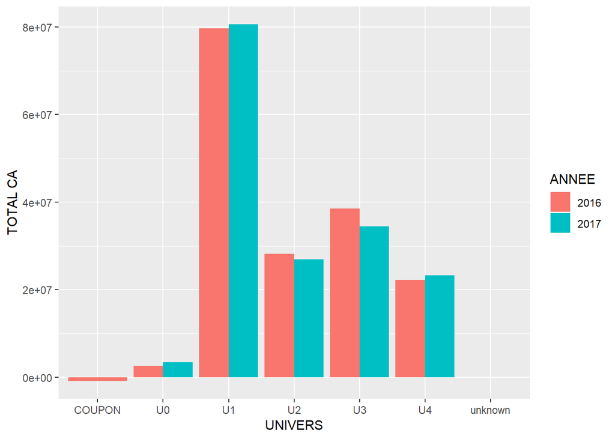

```r
evolution_ca
```

## 3.2 Top marge par univers

3.2 Top par univers Objectif: Afficher le top 5 des familles les plus rentable par univers (en fonction de la marge)

# ETAPE DE PROGRAMMATION

Etape 1 : création d’une nouvelle table agrégée appelé marge_family_univers Agrégation de la marge (somme) par code famille et code univers

```r
#agregation de la marge par code univers et code famille
marge_family_univers<-ligne_article[, .(MARGE=sum(MARGESORTIE)), by=.(CODEUNIVERS, CODEFAMILLE)]
```

Etape 2 : trier la table marge_family_univers

```r
#trie de la table par marge
marge_family_univers<-marge_family_univers[order(CODEUNIVERS,MARGE, decreasing = TRUE),]
```

Etape 3 : Positionner un rang en fonction de la marge, regroupé par code famille et code univers

```r
#créé un rank de la marge par code univers
marge_family_univers <- within(marge_family_univers, rank <- ave(MARGE, CODEUNIVERS,
                                                FUN=function(x)rev(order(x))))
```

Etape 4 : Filtrer pour recuperer uniquement les 5 meilleurs marge par code famille et code univers

```r
#afficher le resultat du rank par code univers et code famille
marge_family_univers_top5<-subset(marge_family_univers, rank<=5)
```

```r
marge_family_univers_top5
```

```
##     CODEUNIVERS CODEFAMILLE       MARGE rank
##  1:     unknown     unknown       10.68    1
##  2:          U4         220 12876658.43    1
##  3:          U4         140   753928.02    2
##  4:          U4         200   282383.97    3
##  5:          U3         120 25890826.74    1
##  6:          U3         110  4300843.68    2
##  7:          U2         090  8140625.82    1
##  8:          U2         070  7742154.86    2
##  9:          U2         130  4425300.30    3
## 10:          U2         210   568901.34    4
## 11:          U1         020 17461174.60    1
## 12:          U1         010 13094263.08    2
## 13:          U1         080 10245218.21    3
## 14:          U1         100  9370663.66    4
## 15:          U1         060  8230891.96    5
## 16:          U0         160  5917722.98    1
## 17:          U0         230    10700.63    2
## 18:          U0         400     1030.55    3
## 19:          U0         900   -12475.90    4
## 20:      COUPON      COUPON  -910804.82    1
```